# Zusammenhang zwischen Wortfolge und Wortstellung in den Nominalphrasen der Weltsprachen

### 3.3.5 Die Reihenfolge von Adjektiv und Umfangsadjektiv in der Nominalphrase “schönen großen Ball”

Um einen hierarchischen Zusammenhang zwischen allen Elementen in der Nominalphrase zu finden, wurde auch die Reihenfolge des Adjektivs “schön” und des Umfangsadjektivs “groß” analysiert.

```r
table(Daten$Adjektiv.Adjektiv.Umfang)
```

```
 Adj-U+Adj  Adj+Adj-U nicht klar
         8         16          2
```

In 16 Sprachen steht “schön” vor “groß” in der Nominalphrase “einen schönen großen roten Ball”, aber in 8 Sprachen steht “groß” vor “schön”. Leider ist in Hindi und Persisch diese Reihenfolge nicht klar, die Informantin für Hindi hatte das Adjektiv “groß” vergessen zu übersetzen und die Informantin für Persisch hatte das Adjektiv “schön” vergessen zu übersetzen.

#### Karte 13: Die Reihenfolge von Adjektiv und Umfangsadjektiv in der Nominalphrase: schönen großen Ball

```r
maps::map("world"
          ,interior = FALSE
          , col = "grey"
          , resolution = 0)
cols <- c("blue", "red", "green3")
mycols10 <- cols[Daten$Adjektiv.Adjektiv.Umfang]
mysymbols <- c(20, 20, 20)
AdjAdjU <- mysymbols[Daten$Adjektiv.Adjektiv.Umfang]
myname <- c("Umfangsadjektiv vor Adjektiv (8)", "Adjektiv vor Umfangsadjektiv (16)", "Nicht klar (2)")
points (Daten$Longitude, Daten$Latitude
       , pch = AdjAdjU
       , col = mycols10)
```

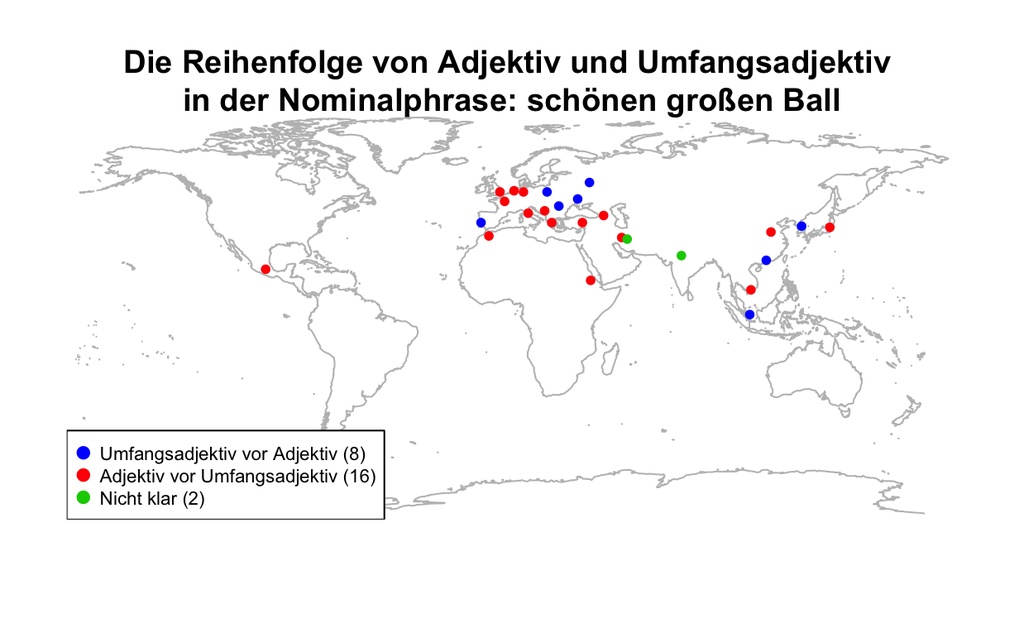

```r
title(main = "Die Reihenfolge von Adjektiv und Umfangsadjektiv
in der Nominalphrase: schönen großen Ball")
legend ("bottomleft"
        , legend = myname
        , pch = AdjAdjU
        , col = cols
        , cex = 0.7
        , pt.cex = 1.5)
```

Karte 13 “Die Reihenfolge von Adjektiv und Umfangsadjektiv in der Nominalphrase: schönen großen Ball” präsentiert das Ergebnis der Analyse von der Reihenfolge “schön + groß” in der Nominalphrase “einen schönen großen roten Ball”.

## 3.4 Zusammenfassung

Nach Payne & Huddleston (2002: 453) ist die Hierarchie von modifizierenden Adjektiven im Englischen: - Evaluative > General Property > Age > Color > Provenance > Manufacture > Type

Gibt es bei jeder Sprache eine Hierarchie für die Wortstellung in der Nominalphrase? Wie stark ist der Zusammenhang? Diese Fragen kann man leider nicht nur mit den Daten der vorliegenden Umfragen beantworten. Jedoch gibt es ein paar Anmerkungen, die wichtig sind. Fast bei jeder Analyse gibt es verschiedene Verteilungen, außer bei der Reihenfolge von “Numerale und Nomen”, da hatten alle Informanten die Numerale vor das Nomen gesetzt.

Die Analyse einzelner Reihenfolgen in der Nominalphrase zeigt uns, dass diese Reihenfolgen miteinander verbunden sind. Wie diese Zusammenhänge zwischen den Wortfolgen und den Wortstellungen in Nominalphrasen sind, wird weiterhin statistisch analysiert.

# 4. Zusammenhang zwischen den Wortfolgen und den Wortstellungen in den Nominalphrasen der erhobenen Sprachen

Nach Greenberg (1966) sind die dominante Reihenfolge und Harmonie-Beziehungen für Erklärung von Universalien am Wichtigsten. Mit Greenberg’s Generalisierung erklärtet man “cross-linguistic-variation”, das Konzept von “competing motivations”. Die zwei miteinander harmonierenden Typen sind OV und VO nach der deklaratorischen Order und die inklusiven Wortstellungen sind in folgender Tabelle (Lehmann 1973; Vennemann 1973). Die Harmonie-Analyse behandelt alle Wordorder als universal, was aber nicht immer passt; Dominante spielt auch eine wichtige Rolle für die Wortorder Typologie (Croft 2002).

```r
Tablle1 <- read.csv("/Users/verawei/Desktop/HA Sprachtypologie/sources/Word Order Types.csv"
               , header = TRUE
               , sep = ";")
Tablle1
```

| The.OV.and.VO.word.order.types | X | X.1 |
| --- | --- | --- |
| Clausal orders | OV | VO |
|  | SV | VS |
|  | VAux | AuxV |
|  | VAdv | AdvV |
|  | VSubr | SubrV |
|  | PurpV | VPurp |
|  | OcompV | VOcomp |
|  | SentQ | QSent |
| Phrasal Orders | Post | Prep |
|  | GN | NG |

[output cut: 5 more lines]

Im Folgenden werden die Zusammenhänge zwischen den Wortfolgen und den Wortstellungen in den Nominalphrasen der erhobenen Sprachen dargestellt. Die Schwerpunkte liegen bei den Zusammenhängen zwischen Wortfolgen und Adjektiv, Artikel, Farbe, Numerale und Genitiv.

## 4.1 Zusammenhang zwischen den Wortfolgen und der Wortstellung der Adjektive und Nomen

Nach vorheriger Analyse wissen wir, dass insgesamt 20 Sprachen eine SVO-Wortfolge haben und 6 Sprachen eine SOV-Wortfolge. Außerdem steht das Adjektiv in 17 Sprachen vor dem Nomen, in 7 Sprachen das Nomen vor dem Adjektiv und in 2 Sprachen gilt beides. Aber wie diese Verteilungen mit einander verbunden sind, wird hier mit verglichen.

```r
Folge1 <- table(Daten$Wortfolge, Daten$Adjektiv.Nomen)
Folge1
```

```
      Adj+N N+Adj No domiant order
  SOV     5     1                0
  SVO    12     6                2
```

Durch die Funktion “table()” bekommen wir eine Table vom Zusammenhang zwischen den Wortfolgen und Wortstellung von Adjektivs und Nomen. Die dominante Order ist hier “SVO-Wortfolgen + Adjektiv vor Nomen”.

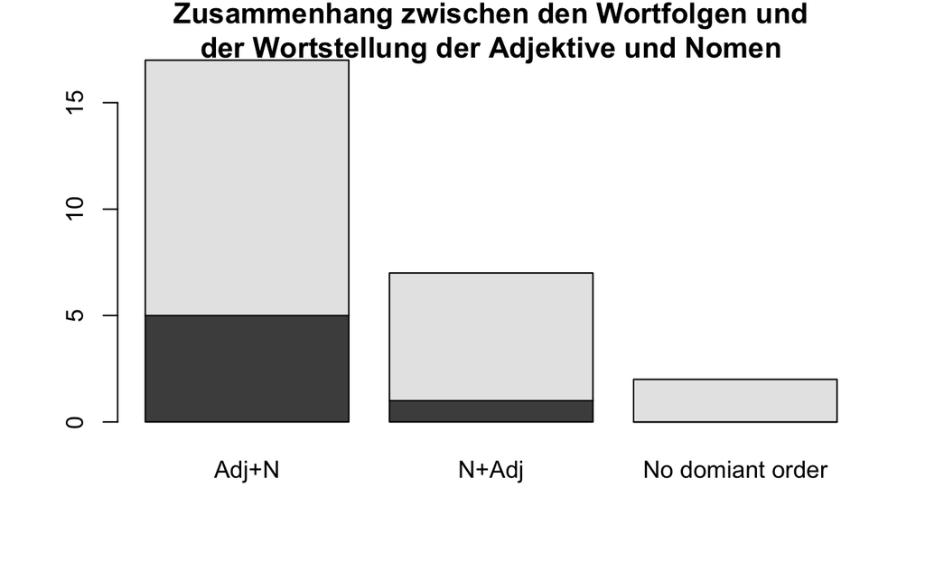

```r
barplot (Folge1
         , main = "Zusammenhang zwischen den Wortfolgen und
der Wortstellung der Adjektive und Nomen"
         )
```

Die Funktion “barplot()” zeigt uns eine visuelle Darstellung über die Verteilung. Hiermit sehen wir, dass die Wortstellung “Adjektiv vor Nomen” die meistverbreiterte Order ist.

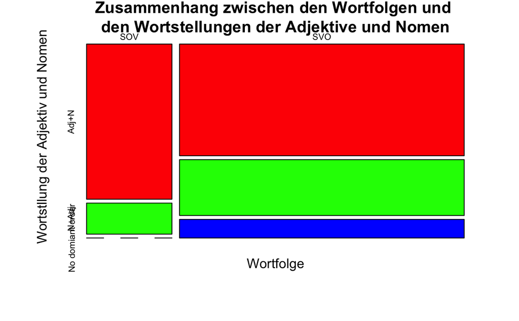

```r
mosaicplot(Folge1
           , color = rainbow(3)
           , xlab = "Wortfolge"
           , ylab = "Wortstllung der Adjektiv und Nomen"
           , main = "Zusammenhang zwischen den Wortfolgen und
den Wortstellungen der Adjektive und Nomen")
```

Die visuelle Darstellung mit der Funktion “mosaicplot()” zeigt eine klare Verteilung. Alle roten Flächen stehen für die Wortstellung “Adjektiv vor Nomen”, alle grünen Flächen für die Wortstellung “Nomen vor Adjektiv” und die blauen Flächen für “beides”. Außerdem sehen wir auf der linken Seite die SOV Sprachen und rechts die SVO Sprachen.

```r
chisq.test(Folge1)
```

```
Chi-Quadrat-Approximation kann inkorrekt sein
```

```
    Pearson's Chi-squared test

data:  Folge1
X-squared = 1.2891, df = 2, p-value = 0.5249
```

Diese statistische Analyse “chisq.test()” zeigt uns, dass der P-Value vom Zusammenhang zwischen den Wortfolgen und den Wortstellungen der Adjektiven und Nomen 0.5249 ist. Dass dieser P-Value > 0.05 ist, bedeutet dass der Zusammenhang zwischen Wortfolgen und Wortstellungen der Adjektive und Nomen von den erhobenen 26 Sprachen nicht signifikant ist.

## 4.2 Zusammenhang zwischen den Wortfolgen und den Wortstellungen der Artikel und Nomen

Unsere vorherige Analyse zeigt uns, dass in insgesamt 23 Sprachen der Artikel vor dem Nomen steht und nur in zwei Sprachen das Nomen vor dem Artikel. Hiermit wird der Zusammenhang zwischen den Wortfolgen und den Artikel-Nomen Wortstellungen berechnet.

```r
Folge2 <- table(Daten$Wortfolge, Daten$Artikel.Nomen)
Folge2
```

```
      DET+N N+DET nicht klar
  SOV     5     0          1
  SVO    18     2          0
```

Die Tabelle zeigt, dass die Order “SVO-Wortfolgen + Artikel vor Nomen” die dominante Order ist.

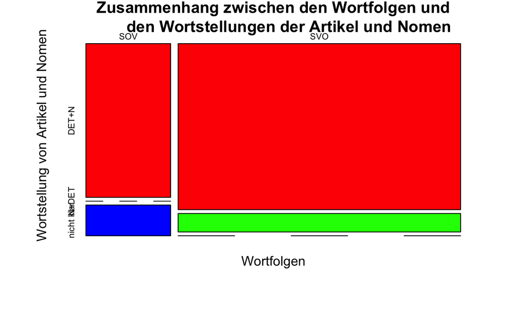

```r
mosaicplot (Folge2
            , color = rainbow(3)
        , xlab = "Wortfolgen"
        , ylab = "Wortstellung von Artikel und Nomen"
        , main = "Zusammenhang zwischen den Wortfolgen und
        den Wortstellungen der Artikel und Nomen ")
```

Mit dem Bild sieht man die Unterschiede, dass rote Flächen die “Artikel vor dem Nomen” sind, blaue Flächen die nicht klare Sprache, und grüne Fläche die Sprachen mit “Nomen vor Artikel”.

```r
chisq.test(Folge2)
```

```
Chi-Quadrat-Approximation kann inkorrekt sein
```

```
    Pearson's Chi-squared test

data:  Folge2
X-squared = 3.9565, df = 2, p-value = 0.1383
```

“Chisq.test()” zeigt, dass der P-Value vom Zusammenhang zwischen den Wortfolgen und den Wortstellungen der Artikel und Nomen 0.1383 beträgt, nämlich P-Value > 0.05. Dies bedeutet, dass der Zusammenhang zwischen den Wortfolgen und Wortstellungen der Artikel und Nomen von den erhobenen 26 Sprachen nicht signifikant ist.

## 4.3 Zusammenhang zwischen den Wortfolgen und den Wortstellungen von Farbe und Nomen

Die Tabelle der Wortfolgen und den Wortstellungen von Farbe und Nomen zeigt uns, dass die dominante Order “SVO-Wortfolgen + Farbe vor Nomen” ist.

```r
Folge3 <- table(Daten$Wortfolge, Daten$Farbe.Nomen)
Folge3
```

```
      Fa+N N+Fa
  SOV    5    1
  SVO   13    7
```

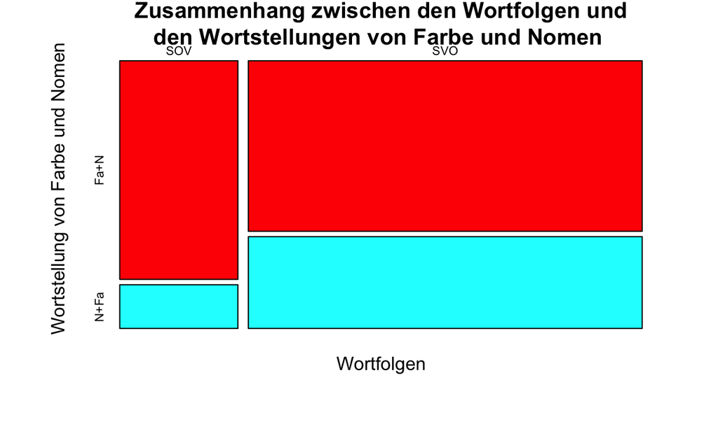

```r
mosaicplot (Folge3
        , color = rainbow(2)
        , xlab = "Wortfolgen"
        , ylab = "Wortstellung von Farbe und Nomen"
        , main = "Zusammenhang zwischen den Wortfolgen und
den Wortstellungen von Farbe und Nomen ")
```

Auf dem Bild sind alle roten Flächen die Sprachen, in denen Farbe vor Nomen steht, und blaue Flächen die Sprachen, in denen Nomen vor Farbe steht.

```r
chisq.test(Folge3)
```

```
Chi-Quadrat-Approximation kann inkorrekt sein
```

```
    Pearson's Chi-squared test with Yates' continuity correction

data:  Folge3
X-squared = 0.12187, df = 1, p-value = 0.727
```

Der P-Value von der statistischen Analyse “chisq.test()” ist 0.727. Das bedeutet, dass der Zusammenhang zwischen den Wortfolgen und den Wortstellungen von Adjektiv-Farbe und Nomen von den erhobenen 26 Sprachen nicht signifikant ist, da der p-Value > 0.05 beträgt.

## 4.4 Zusammenhang zwischen den Wortfolgen und den Wortstellungen von Numerale und Nomen

Die vorherige Analyse zeigt, dass in allen erhobenen Sprachen die Numerale vor dem Nomen steht. Daher hat die Tabelle von den Wortfolgen und Wortstellung von Numerale und Nomen nur zwei Verteilungen.

```r
Folge4 <- table(Daten$Wortfolge, Daten$Numeral.Nomen)
Folge4
```

```
      Num+N
  SOV     6
  SVO    20
```

Die Order “SVO-Wortfolgen + Numerale vor Nomen” ist die dominante Order.

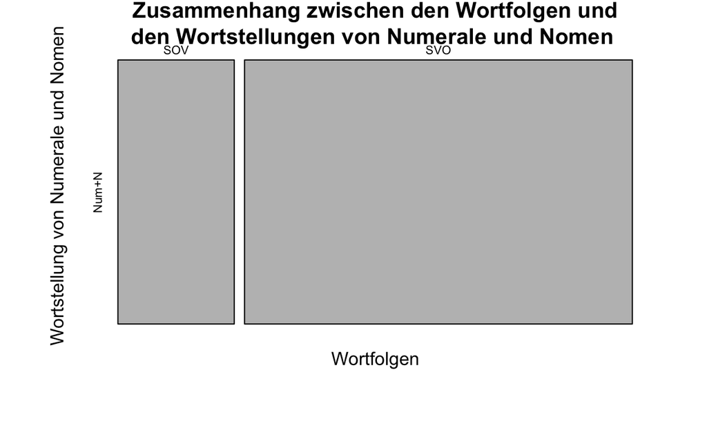

```r
mosaicplot (Folge4
        , xlab = "Wortfolgen"
        , ylab = "Wortstellung von Numerale und Nomen"
        , main = "Zusammenhang zwischen den Wortfolgen und
den Wortstellungen von Numerale und Nomen ")
```

```r
chisq.test(Folge4)
```

```
    Chi-squared test for given probabilities

data:  Folge4
X-squared = 7.5385, df = 1, p-value = 0.00604
```

## 4.5 Zusammenhang zwischen den Wortfolgen und den Wortstellungen von Genitiv und Nomen

Die vorherige Analyse zeigt, dass der Genitiv in 9 Sprachen vor dem Nomen steht, in 15 Sprachen jedoch nach dem Nomen und in zwei Sprachen diese Reihenfolge nicht bekannt ist. Hiermit wird der Zusammenhang zwischen den Wortfolgen und den Wortstellungen von Genitiv und Nomen berechnet.

```r
Folge5 <- table(Daten$Wortfolge, Daten$Musik.Mozart)
Folge5
```

```
      MoMu MuMo nicht klar
  SOV    5    0          1
  SVO    4   15          1
```

Die Tabelle zeigt, dass die Order “SVO-Wortfolgen + Nomen vor Genitiv” die dominante Order ist.

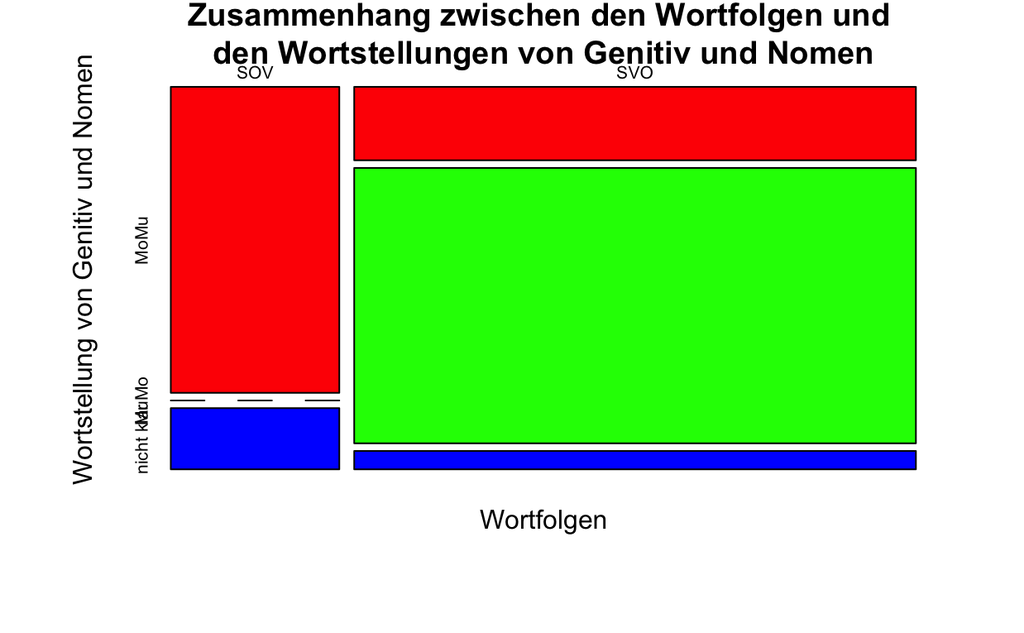

```r
mosaicplot(Folge5
           , color = rainbow(3)
           , xlab = "Wortfolgen"
           , ylab = "Wortstellung von Genitiv und Nomen"
           , main = "Zusammenhang zwischen den Wortfolgen und
den Wortstellungen von Genitiv und Nomen")
```

Die grüne Fläche ist die dominante Order “Nomen vor Genitiv”, die rote Fläche ist die Order “Genitiv vor Nomen” und die blaue Fläche sind die nicht klaren Sprache für diese Wortstellung. Außerdem sieht man einen klaren Unterschied für diese Wortstellungen zwischen SOV-Sprachen und SVO-Sprachen. Für die SOV-Sprachen ist “Genitiv vor Nomen” die dominante Order, jedoch ist die “Nomen vor Genitiv” die dominante Order für die SVO-Sprachen.

```r
chisq.test(Folge5)
```

```
Chi-Quadrat-Approximation kann inkorrekt sein
```

```
    Pearson's Chi-squared test

data:  Folge5
X-squared = 10.665, df = 2, p-value = 0.004832
```

Mit der statistischen Analyse “chisq.test()” liegt der P-Value bei 0.004832. Wenn der P-Value < 0.01 ist, bedeutet dies, dass der Zusammenhang zwischen den Wortfolgen und den Wortstellungen von Genitiv und Nomen bei den erhobenen 26 Sprachen signifikant ist. Das Bild der Funktion “mosaicplot()” zeigt uns, dass diese Wortstellung stark von den Wortfolgen abhängig ist.

## 4.6 Zusammenfassung

Diese Ergebnisse sprechen auch dafür, dass es harmonische Zusammenhänge zwischen den Wortfolgen und den Wortstellungen gibt, aber nicht für alle Wortorder oder alle Sprachen. Außerdem sind nur 26 Sprachen in dieser Analyse berücksichtigt, wenn man andere Sprachen oder mehr Sprachen mit einander vergleicht, resultieren vielleicht andere signifikante Zusammenhänge.

# 5. Allgemeine Diskussion und Ausblick

## 5.1 Kritiken

In vielen Übersetzungsbögen ist die Bedeutung von einzelnen Wörtern nicht klar markiert oder sogar nicht aufgeschrieben, wie für Persisch und Koreanisch. Man kann nur mit dem Wörterbuch oder Übersetzungsprogrammen wie Google Übersetzer die Bedeutung vom einzelnen Wort raussuchen, aber meistens ist diese Vorgehensweise nicht exakt. Die Wortart kann man zwar feststellen, aber nicht die genaue Bedeutung und ihre grammatische Feinheit.

Bei der Übersetzung vom Satz 1" Ich koche Suppe" wird das Subjekt in vielen Sprachen nicht angegeben. Denn in manchen Sprachen wird das Subjekt “ich” mit der Endung des Verbs markiert.

Die Übersetzungsbögen sind auf Deutsch geschrieben. Beim Übersetzung von einer Sprache in die andere kann die Wortstellung im Satz von der angegebenen Sprache beeinflusst werden. Für weitere Forschung kann man vielleicht mit Transkriptionen von Tonaufnahmen oder von frei gesprochenen Gesprächen arbeiten. Allerdings kann man sagen, dass die Datenerhebung mit dem Übersetzungsbogen sehr effektiv ist.

## 5.2 Ausblicken

Wenn man die Wortstellung in diesen fünf Sätzen in den erhobenen 26 Sprachen diskutiert, bekommt man eigentlich nicht alle Wortstellungsmöglichkeiten von diesen Sprachen. Eine Ausnahme ist zum Beispiel Chinesisch, die Wortstellung im Chinesischen kann sowohl “Subjekt-Verb-Objekt (SVO)” als auch “Subjekt-Objekt-Verb (SOV)” sein. Die Wortfolge im chinesischen Satz kann die Bedeutung des Satzes stark verändern, wie in den folgenden Sätzen nach Jiang (2009):

- 1. Subjekt + Negation + Verb + Objekt
- Sichuan ren bu pa la
- Sichuan person not fear spicy
- “Sichuaners do not (fear their food) being spicy.”
- 2. Subjekt + Objekt + Negation + Verb
- Hubei ren la bu pa
- Hubei person spicy not fear
- “(Their food) being spicy is not fearful matter to Hubeiners.”
- 3. Subjekt + Verb + Negation + Objekt
- Hunan ren pa bu la
- Hunan person fear not spicy
- “Hunaners fear that (their food) is not spicy.”

Die Beispiele nach Jiang (2009) zeigen, dass es im Chinesischen im Negationssatz verschiedene Wortfolgen geben kann. Für die weitere Forschung ist das Thema “Negation im Satz” sehr interessant, um zu sehen, wie viele Möglichkeiten es bei der Negation in jeder Sprache gibt und wie die Zusammenhänge und Verteilungen der Weltsprachen dies bezüglich sind.

# Literatur- und Quellenverzeichnis

- Croft W. Typology and universals[M]. Cambridge University Press, 2002.
- Greenberg J H. Synchronic and diachronic universals in phonology[J]. Language, 1966, 42(2): 508-517.
- Greenberg Joseph H. Language universals, with special reference to feature hierarchies[J]. The Hague, Mouton, 1966.
- Haspelmath M.: Sprachen der Welt. Max-Planck-Institut für evolutionäre Anthropologie (1999-2005) http://home.uni-leipzig.de/muellerg/su/haspelmath.pdf (aufgerufen am 14.03.2018)
- Haarmann H. Elementare Wortordnung in den Sprachen der Welt: Dokumentation und Analysen zur Entstehung von Wortfolgemustern[M]. Buske Verlag, 2004.
- Jiang W. Acquisition of word order in Chinese as a foreign language[M]. Walter de Gruyter, 2009.
- Kahl T, Metzeltin M. Sprachtypologie: ein Methoden-und Arbeitsbuch für Balkanologen, Romanisten und allgemeine Sprachwissenschaftler[M]. Harrassowitz Verlag, 2015.
- Kotowski S. Adjectival Modification and Order Restrictions: The Influence of Temporariness on Prenominal Word Order[M]. Walter de Gruyter GmbH & Co KG, 2016.
- Kwon H J. Eine kontrastive Beschreibung des Serbokroatischen und des Koreanischen: unter besonderer Berücksichtigung der Wortfolge[D]., 1996.
- Payne J, Huddleston R D. Nouns and noun phrases[J]. 2002.
- Szwedek A J. The thematic structure of the sentence in English and Polish: Sentence stress and word order[M]. Peter Lang, 2011.
- Wortstellung im Sprachvergleich: (deutsch-niederländisch-polnisch-ungarisch) [M]. Julius Groos, 2001.
- Koordinaten für die erhobenen Sprachen: http://wals.info/languoid (aufgerufen am 22.02.2018)
- Nachschlagen von R: https://rseek.org